# Programming Assignment 3

Michael Raminski (mraminski@gmail.com)

November 19, 2017

email address: mraminski@gmail.com

# Bureau of Labor Statistics Project

# Part 1

## Read in data, convert from wide to long, manipulate data for graphing purposes

```r
sf_oak_metro <- read.csv("sf_oak_metro.csv")

long_sf_oak_metro <- sf_oak_metro %>%
  gather(valuation, value, Jan.1990:Dec.2016) #convert from wide to long
kable(long_sf_oak_metro) %>%
  head
```

```
[1] "Series.ID              valuation        value"
[2] "---------------------  ----------  ----------"
[3] "LAUMT064186000000003   Jan.1990           3.5"
[4] "LAUMT064186000000004   Jan.1990       70296.0"
[5] "LAUMT064186000000005   Jan.1990     1952945.0"
[6] "LAUMT064186000000006   Jan.1990     2023241.0"
```

```r
long_sf_oak_metro <- long_sf_oak_metro %>%
  mutate(date = as.Date(gsub("[.]", "01", valuation), "%B%d%Y"), #convert to date format
         year = year(date))

long_sf_oak_metro %>% head
```

```
             Series.ID valuation     value       date year
1 LAUMT064186000000003  Jan.1990       3.5 1990-01-01 1990
2 LAUMT064186000000004  Jan.1990   70296.0 1990-01-01 1990
3 LAUMT064186000000005  Jan.1990 1952945.0 1990-01-01 1990
4 LAUMT064186000000006  Jan.1990 2023241.0 1990-01-01 1990
5 LAUMT064186000000003  Feb.1990       3.3 1990-02-01 1990
6 LAUMT064186000000004  Feb.1990   66517.0 1990-02-01 1990
```

## Graph data using ggplot

### Filter data with dplyr to get subset of only “Unemployment Rate” data, then graph results

```r
unemployment_rate <- long_sf_oak_metro %>%
  filter(Series.ID == "LAUMT064186000000003") %>% #data set with only Unemployment Rate
  select(value, date, year)
unemployment_rate %>% head
```

```
  value       date year
1   3.5 1990-01-01 1990
2   3.3 1990-02-01 1990
3   3.2 1990-03-01 1990
4   3.4 1990-04-01 1990
5   3.3 1990-05-01 1990
6   3.5 1990-06-01 1990
```

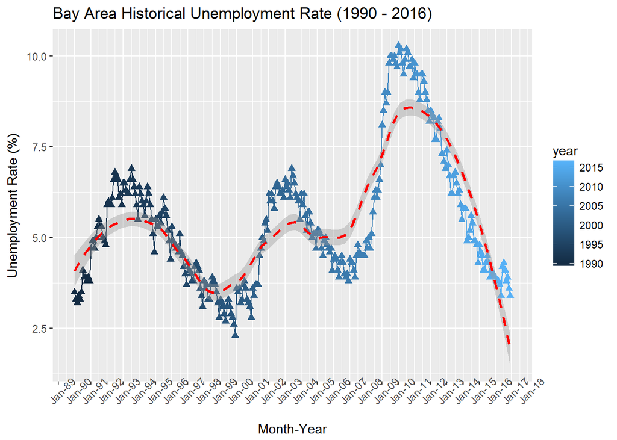

```r
unemployment_rate %>%
  ggplot(aes(date, value, color = year)) +
  geom_line() +
  geom_point(pch=17, size=2) +
  geom_smooth(method="loess", color="red", linetype=2, span = .5) +
  scale_x_date(labels = date_format("%b-%y"), date_breaks = "1 year") +
  theme(axis.text.x = element_text(angle=45)) +
  labs(title="Bay Area Historical Unemployment Rate (1990 - 2016)", x="Month-Year", y="Unemployment Rate (%)")
```

### Filter data with dplyr to get subset of only “Unemployed Persons” data, then graph results

```r
unemployment <- long_sf_oak_metro %>%
  filter(Series.ID == "LAUMT064186000000004") %>% #data set with only Unemployed Persons
  select(value, date, year)
unemployment %>% head
```

```
  value       date year
1 70296 1990-01-01 1990
2 66517 1990-02-01 1990
3 63840 1990-03-01 1990
4 67539 1990-04-01 1990
5 67268 1990-05-01 1990
6 71436 1990-06-01 1990
```

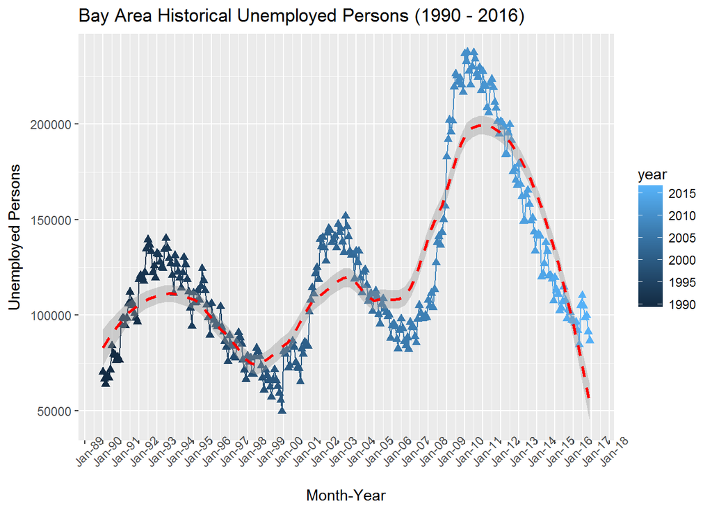

```r
unemployment %>%
  ggplot(aes(date, value, color = year)) +
  geom_line() +
  geom_point(pch=17, size=2) +
  geom_smooth(method="loess", color="red", linetype=2, span = .5) +
  scale_x_date(labels = date_format("%b-%y"), date_breaks = "1 year") +
  theme(axis.text.x = element_text(angle=45)) +
  labs(title="Bay Area Historical Unemployed Persons (1990 - 2016)", x="Month-Year", y="Unemployed Persons")
```

### Filter data with dplyr to get subset of only “Employed Persons” data, then graph results

```r
employment <- long_sf_oak_metro %>%
  filter(Series.ID == "LAUMT064186000000005") %>% #data set with only Employed Persons
  select(value, date, year)
employment %>% head
```

```
    value       date year
1 1952945 1990-01-01 1990
2 1948964 1990-02-01 1990
3 1951817 1990-03-01 1990
4 1942696 1990-04-01 1990
5 1945080 1990-05-01 1990
6 1955609 1990-06-01 1990
```

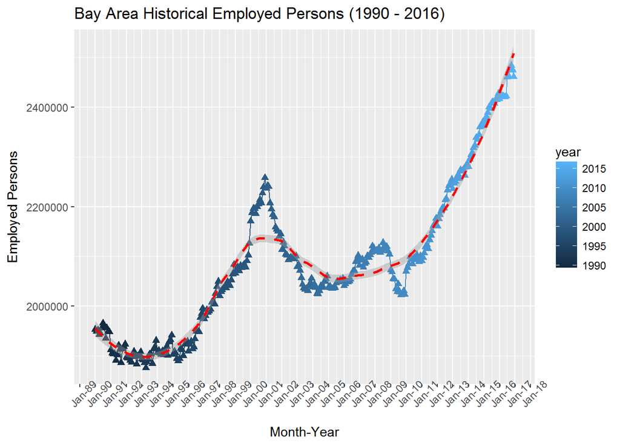

```r
employment %>%
  ggplot(aes(date, value, color = year)) +
  geom_line() +
  geom_point(pch=17, size=2) +
  geom_smooth(method="loess", color="red", linetype=2, span = .5) +
  scale_x_date(labels = date_format("%b-%y"), date_breaks = "1 year") +
  theme(axis.text.x = element_text(angle=45)) +
  labs(title="Bay Area Historical Employed Persons (1990 - 2016)", x="Month-Year", y="Employed Persons")
```

### Filter data with dplyr to get subset of only “Labor Force” data, then graph results

```r
laborforce <- long_sf_oak_metro %>%
  filter(Series.ID == "LAUMT064186000000006") %>% #data set with only Labor Force
  select(value, date, year)
laborforce %>% head
```

```
    value       date year
1 2023241 1990-01-01 1990
2 2015481 1990-02-01 1990
3 2015657 1990-03-01 1990
4 2010235 1990-04-01 1990
5 2012348 1990-05-01 1990
6 2027045 1990-06-01 1990
```

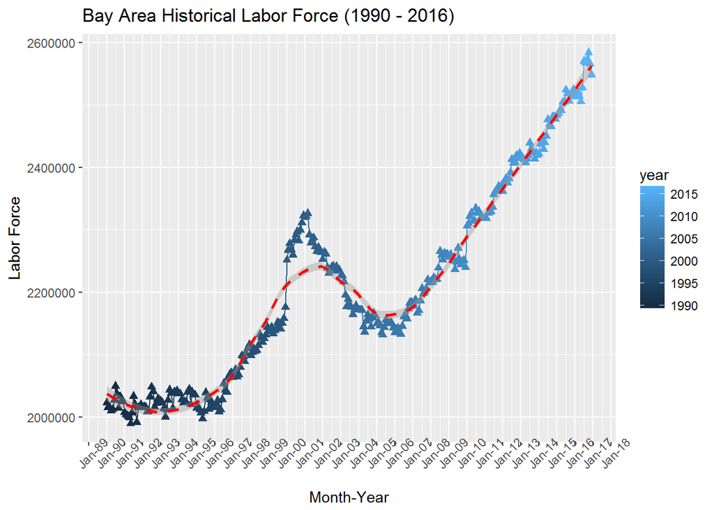

```r
laborforce %>%
  ggplot(aes(date, value, color = year)) +
  geom_line() +
  geom_point(pch=17, size=2) +
  geom_smooth(method="loess", color="red", linetype=2, span = .5) +
  scale_x_date(labels = date_format("%b-%y"), date_breaks = "1 year") +
  theme(axis.text.x = element_text(angle=45)) +
  labs(title="Bay Area Historical Labor Force (1990 - 2016)", x="Month-Year", y="Labor Force")
```

# Part 2

#### Using employment data from the “gz_2010_us_050_00_20m.json” and “california_counties_monthly_employment_2016.tsv” files, I will create two maps. The first, is a static choropleth map showing the California unemployment rates by county for December 2016. The second map, is an interactive chorpleth map, using Shiny, where the user can toggle between all months of 2016 to see the monthly California unemployment rates by county.

## Read in data from tsv and json files and manipulate data using dplyr

```r
ca_counties_tsv <- read_tsv("california_counties_monthly_employment_2016.tsv") %>%
  mutate(month = month(period)) #Add month number 1-12
ca_counties_tsv <- ca_counties_tsv %>%
  select(fips_county, unemployed_rate, month) #reduce the data set to only the relevant fields
ca_counties_tsv %>% head
```

```
# A tibble: 6 x 3
  fips_county unemployed_rate month
        <chr>           <dbl> <dbl>
1         001             4.3     1
2         003             5.4     1
3         005             6.6     1
4         007             7.3     1
5         009             6.3     1
6         011            22.3     1
```

```r
ca_counties_json <- geojson_read("gz_2010_us_050_00_20m.json", what = "sp")
ca_counties_json <- ca_counties_json %>%
  filter(STATE == "06") %>% #Filter dataset down to just California
  mutate(fips_county = COUNTY)
ca_counties_json %>% head
```

```
class       : SpatialPolygonsDataFrame
features    : 6
extent      : -123.093, -119.309, 37.18311, 41.18389  (xmin, xmax, ymin, ymax)
coord. ref. : +proj=longlat +datum=WGS84 +no_defs +ellps=WGS84 +towgs84=0,0,0
variables   : 7
# A tibble: 6 x 7
          GEO_ID  STATE COUNTY     NAME   LSAD CENSUSAREA fips_county
          <fctr> <fctr> <fctr>   <fctr> <fctr>      <dbl>      <fctr>
1 0500000US06005     06    005   Amador County    594.583         005
2 0500000US06021     06    021    Glenn County   1313.947         021
3 0500000US06033     06    033     Lake County   1256.464         033
4 0500000US06043     06    043 Mariposa County   1448.816         043
5 0500000US06055     06    055     Napa County    748.362         055
6 0500000US06089     06    089   Shasta County   3775.402         089
```

## Merge datasets using sp package

```r
ca_joined <- sp::merge(ca_counties_json, ca_counties_tsv, duplicateGeoms = TRUE)
ca_joined %>% head
```

```
class       : SpatialPolygonsDataFrame
features    : 6
extent      : -121.0275, -120.0724, 38.22128, 38.70903  (xmin, xmax, ymin, ymax)
coord. ref. : +proj=longlat +datum=WGS84 +no_defs +ellps=WGS84 +towgs84=0,0,0
variables   : 9
# A tibble: 6 x 9
  fips_county         GEO_ID  STATE COUNTY   NAME   LSAD CENSUSAREA
*      <fctr>         <fctr> <fctr> <fctr> <fctr> <fctr>      <dbl>
1         005 0500000US06005     06    005 Amador County    594.583
2         005 0500000US06005     06    005 Amador County    594.583
3         005 0500000US06005     06    005 Amador County    594.583
4         005 0500000US06005     06    005 Amador County    594.583
5         005 0500000US06005     06    005 Amador County    594.583
6         005 0500000US06005     06    005 Amador County    594.583
# ... with 2 more variables: unemployed_rate <dbl>, month <dbl>
```

## Show choropleth map for California Unemployment Rates in December by Quantile (Darker Red shows higher unemployment)

```r
ca_joined_dec <- ca_joined %>%
  filter(month == 12) #show December 2016 only
ca_joined_dec %>% head
```

```
class       : SpatialPolygonsDataFrame
features    : 6
extent      : -123.093, -119.309, 37.18311, 41.18389  (xmin, xmax, ymin, ymax)
coord. ref. : +proj=longlat +datum=WGS84 +no_defs +ellps=WGS84 +towgs84=0,0,0
variables   : 9
# A tibble: 6 x 9
  fips_county         GEO_ID  STATE COUNTY     NAME   LSAD CENSUSAREA
*      <fctr>         <fctr> <fctr> <fctr>   <fctr> <fctr>      <dbl>
1         005 0500000US06005     06    005   Amador County    594.583
2         021 0500000US06021     06    021    Glenn County   1313.947
3         033 0500000US06033     06    033     Lake County   1256.464
4         043 0500000US06043     06    043 Mariposa County   1448.816
5         055 0500000US06055     06    055     Napa County    748.362
6         089 0500000US06089     06    089   Shasta County   3775.402
# ... with 2 more variables: unemployed_rate <dbl>, month <dbl>
```

```r
pal <- colorQuantile("Reds", domain = ca_joined_dec$unemployed_rate, n=10)
map <- leaflet(ca_joined_dec)
map %>% addPolygons(
  fillColor = ~pal(ca_joined_dec$unemployed_rate),
  weight = 2,
  opacity = 1,
  color = "white",
  dashArray = "3",
  fillOpacity = 0.7) %>%
addLegend(pal = pal, values = ~ca_joined_dec$unemployed_rate, opacity = 0.7, title = "Unemployment Quantile",
                position = "bottomright")
```

[interactive chart not shown]

## Show choropleth map for California on Shiny App, allowing user to toggle between months (code not active in Markdown file).

Link to Shiny App: https://ski2488.shinyapps.io/RaminskiAssignment3/

```r
shinyUI(fluidPage(
  titlePanel("Interactive California Employment Statistics Map"),
  sidebarLayout(sidebarPanel(
    selectInput("MonthSelector",
                label = "Select the Month:",
                choice = c(1:12),
                selected = 12)
  ),
  mainPanel(
    leafletOutput("showThePlot")
  ))
))

shinyServer(function(input, output) {
  filtered_month <- reactive ({ca_joined %>% filter(month == input$MonthSelector)
  })
  colorpal <- reactive({colorQuantile("Reds", domain = ca_joined$unemployed_rate, n=10)
  })

  output$showThePlot <- renderLeaflet({
    leaflet(filtered_month()) %>% addPolygons(
      fillColor = ~pal(ca_joined$unemployed_rate),
      weight = 2,
      opacity = 1,
      color = "white",
      dashArray = "3",
      fillOpacity = 0.7) %>%
      addLegend(pal = pal, values = ~ca_joined$unemployed_rate, opacity = 0.7, title = "Unemployment Quantile",
                position = "bottomright")
  })

  observe({
    pal <- colorpal()

    leafletProxy("showThePlot", data = filtered_month()) %>% addPolygons(
      fillColor = ~pal(ca_joined$unemployed_rate),
      weight = 2,
      opacity = 1,
      color = "white",
      dashArray = "3",
      fillOpacity = 0.7)
    #      addLegend(pal = pal, values = ~ca_joined$unemployed_rate, opacity = 0.7, title = "Unemployment Quantile",
    #                                    position = "bottomright")
  })
})
```